# Web Scraping

November 3, 2025

Jo Hardin

# Agenda 11/03/25

1. HTML / web scraping
2. css selectors
3. `rvest`

## Important tool

Our approach to web scraping relies on the Chrome browser and an extension called SelectorGadget. Download them here:

- [Chrome](https://www.google.com/chrome/)
- [SelectorGadget from Chrome](https://chromewebstore.google.com/detail/selectorgadget/mhjhnkcfbdhnjickkkdbjoemdmbfginb?hl=en&pli=1) or [SelectorGadget vignette etc.](https://selectorgadget.com/)

## Data Acquisition

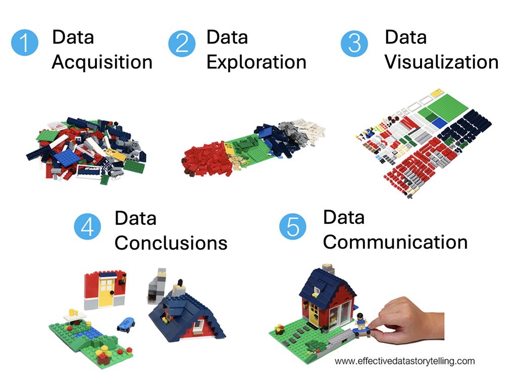

Based on https://www.effectivedatastorytelling.com/post/a-deeper-dive-into-lego-bricks-and-data-stories, original source: https://www.linkedin.com/learning/instructors/bill-shander

## Reading The Student Life

How often do you read The Student Life?  
a. Every day  
b. 3-5 times a week  
c. Once a week  
d. Rarely

## Reading The Student Life

What do you think is the most common word in the titles of The Student Life opinion pieces?

## Analyzing The Student Life

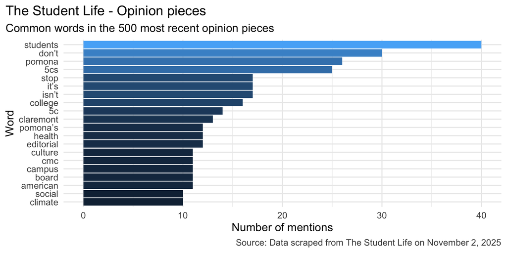

## Reading The Student Life

How do you think the sentiments in opinion pieces in The Student Life compare across authors?  
Roughly the same?  
Wildly different?  
Somewhere in between?

## Analyzing The Student Life

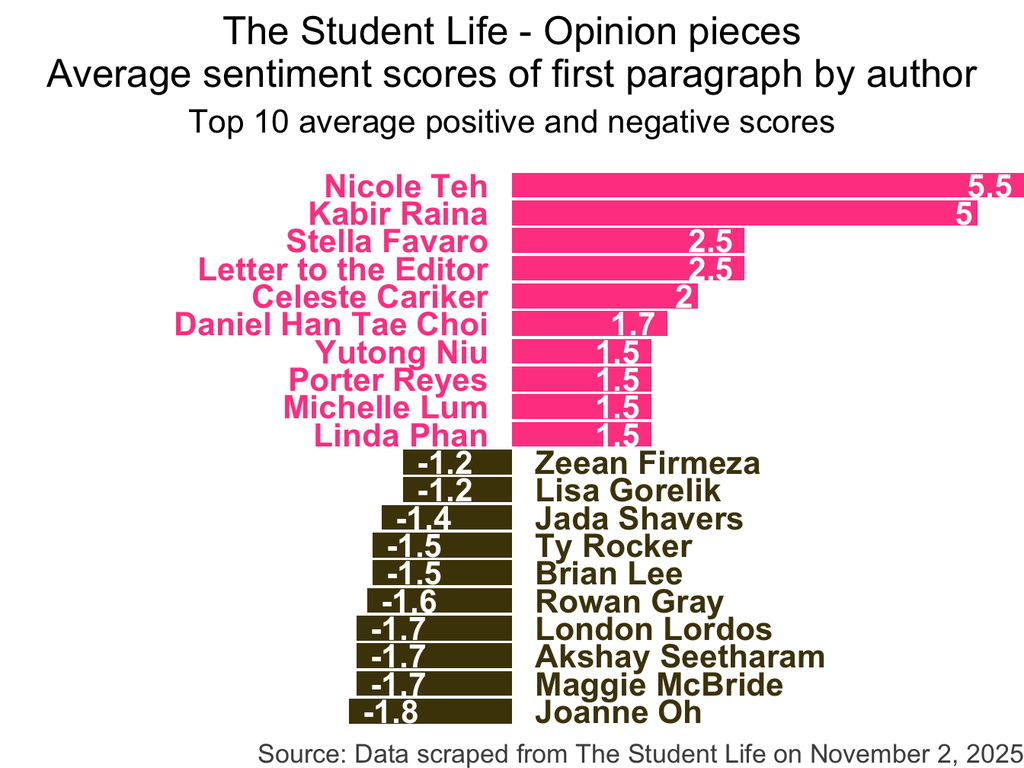

## All of this analysis is done in R!

(mostly) with tools you already know!

## Common words in The Student Life titles

Code for the earlier plot:

```r
data(stop_words) # from tidytext
tsl_opinion_titles |>
  tidytext::unnest_tokens(word, title) |>
  anti_join(stop_words) |>
  count(word, sort = TRUE) |>
  slice_head(n = 20) |>
  mutate(word = fct_reorder(word, n)) |>
  ggplot(aes(y = word, x = n, fill = log(n))) +
  geom_col(show.legend = FALSE) +
  theme_minimal(base_size = 16) +
  labs(
    x = "Number of mentions",
    y = "Word",
    title = "The Student Life - Opinion pieces",
    subtitle = "Common words in the 500 most recent opinion pieces",
    caption = "Source: Data scraped from The Student Life on November 2, 2025"
  ) +
  theme(
    plot.title.position = "plot",
    plot.caption = element_text(color = "gray30")
  )
```

## Avg sentiment scores of first paragraph

Code for the earlier plot:

```r
afinn_sentiments <- get_sentiments("afinn") # need tidytext and textdata
tsl_opinion_titles |>
  tidytext::unnest_tokens(word, first_p) |>
  anti_join(stop_words) |>
  left_join(afinn_sentiments) |>
  group_by(authors, title) |>
  summarize(total_sentiment = sum(value, na.rm = TRUE), .groups = "drop") |>
  group_by(authors) |>
  summarize(
    n_articles = n(),
    avg_sentiment = mean(total_sentiment, na.rm = TRUE),
  ) |>
  filter(n_articles > 1 & !is.na(authors)) |>
  arrange(desc(avg_sentiment)) |>
  slice(c(1:10, 69:78)) |>
  mutate(
    authors = fct_reorder(authors, avg_sentiment),
    neg_pos = if_else(avg_sentiment < 0, "neg", "pos"),
    label_position = if_else(neg_pos == "neg", 0.25, -0.25)
  ) |>
  ggplot(aes(y = authors, x = avg_sentiment)) +
  geom_col(aes(fill = neg_pos), show.legend = FALSE) +
  geom_text(
    aes(x = label_position, label = authors, color = neg_pos),
    hjust = c(rep(1, 10), rep(0, 10)),
    show.legend = FALSE,
    fontface = "bold"
  ) +
  geom_text(
    aes(label = round(avg_sentiment, 1)),
    hjust = c(rep(1.25, 10), rep(-0.25, 10)),
    color = "white",
    fontface = "bold"
  ) +
  scale_fill_manual(values = c("neg" = "#4d4009", "pos" = "#FF4B91")) +
  scale_color_manual(values = c("neg" = "#4d4009", "pos" = "#FF4B91")) +
  scale_x_continuous(breaks = -5:5, minor_breaks = NULL) +
  scale_y_discrete(breaks = NULL) +
  coord_cartesian(xlim = c(-5, 5)) +
  labs(
    x = "negative  ←     Average sentiment score (AFINN)     →  positive",
    y = NULL,
    title = "The Student Life - Opinion pieces\nAverage sentiment scores of first paragraph by author",
    subtitle = "Top 10 average positive and negative scores",
    caption = "Source: Data scraped from The Student Life on November 2, 2025"
  ) +
  theme_void(base_size = 16) +
  theme(
    plot.title = element_text(hjust = 0.5),
    plot.subtitle = element_text(
      hjust = 0.5,
      margin = unit(c(0.5, 0, 1, 0), "lines")
    ),
    axis.text.y = element_blank(),
    plot.caption = element_text(color = "gray30")
  )
```

## Where is the data coming from?

https://tsl.news/category/opinions/

[figure not shown]

## Where is the data coming from?

[figure not shown]

```r
tsl_opinion_titles
```

```
# A tibble: 500 × 4
  title                            authors date                first_p
  <chr>                            <chr>   <dttm>              <chr>
1 Stop buying your books           Sarah … 2025-04-04 08:03:00 from b…
2 The case for fleeing the country Alex B… 2025-04-04 07:27:00 when t…
3 Tolerate thy neighbor            Parker… 2025-04-04 07:22:00 it’s s…
4 Confronting furry hate           Xavier… 2025-04-04 07:16:00 furrie…
5 Shame on the governor: Gavin Ne… Akshay… 2025-03-28 06:56:00 gavin …
6 Accessibility at the 5Cs requir… Zena A… 2025-03-28 06:42:00 althou…
# ℹ 494 more rows
```

# HTML / Web scraping

## Scraping the web: what? why?

- Increasing amount of data is available on the web
- These data are provided in an unstructured format: you can always copy & paste, but it’s time-consuming and prone to errors
- Web scraping is the process of extracting information automatically and transforming it into a structured dataset
- Two different scenarios:
  - Screen scraping: extract data from source code of website, with html parser (easy) or regular expression matching (less easy).
  - Web APIs (application programming interface): website offers a set of structured http requests that return JSON or XML files.

## Hypertext Markup Language

Much of the data on the web is available as HTML - while it is structured (hierarchical), often it is not immediately available in a form useful for analysis (flat / tidy).

```html
<html>
  <head>
    <title>This is a title</title>
  </head>
  <body>
    <p align="center">Hello world!</p>
    <br>
    <div class="name" id="first">John</div>
    <div class="name" id="last">Doe</div>
    <div class="contact">
      <div class="home">555-555-1234</div>
      <div class="home">555-555-2345</div>
      <div class="work">555-555-9999</div>
      <div class="fax">555-555-8888</div>
    </div>
  </body>
</html>
```

## Some HTML elements

- `<html>`: start of the HTML page
- `<head>`: header information (metadata about the page)
- `<body>`: everything that is on the page
- `<p>`: paragraph
- `<b>`: bold
- `<table>`: table
- `<div>`: a container to group content together (“division”) (used to group other HRML elements together)
- `<a>`: the “anchor” element that creates a hyperlink

## HTML attribute

An **attribute** in HTML is a name–value pair that gives extra information about an element. It sits inside the opening tag and modifies the element’s behavior, appearance, identity, or data.

Think of the **attribute** as the argument to the **element** (which would be the function in this analogy).

## rvest

- The **rvest** package makes basic processing and manipulation of HTML data straight forward
- It is designed to work with pipelines built with `|>`
- rvest.tidyverse.org

```r
library(rvest)
```

[figure not shown]

## rvest

Core functions:

- `read_html()` - read HTML data from a url or character string.
- `html_elements()` - select specified elements from the HTML document using CSS selectors.
- `html_element()` - select a single element from the HTML document using CSS selectors.
- `html_table()` - parse an HTML table into a data frame.
- `html_text()` / `html_text2()` - extract element’s text content.
- `html_name` - extract a element’s name(s).
- `html_attrs` - extract all attributes.
- `html_attr` - extract attribute value(s) by name.

## html & rvest

```r
html <-
  '<html>
  <head>
    <title>This is a title</title>
  </head>
  <body>
    <p align="center">Hello world!</p>
    <br>
    <div class="name" id="first">John</div>
    <div class="name" id="last">Doe</div>
    <div class="contact">
      <div class="home">555-555-1234</div>
      <div class="home">555-555-2345</div>
      <div class="work">555-555-9999</div>
      <div class="fax">555-555-8888</div>
    </div>
  </body>
</html>'
```

```r
read_html(html)
```

```
{html_document}
<html>
[1] <head>\n<meta http-equiv="Content-Type" content="text/html; charset=UTF-8 ...
[2] <body>\n    <p align="center">Hello world!</p>\n    <br><div class="name" ...
```

## Selecting elements

```r
read_html(html) |> html_elements("p")
```

```
{xml_nodeset (1)}
[1] <p align="center">Hello world!</p>
```

```r
read_html(html) |> html_elements("p") |> html_text()
```

```
[1] "Hello world!"
```

```r
read_html(html) |> html_elements("p") |> html_name()
```

```
[1] "p"
```

```r
read_html(html) |> html_elements("p") |> html_attrs()
```

```
[[1]]
   align
"center"
```

```r
read_html(html) |> html_elements("p") |> html_attr("align")
```

```
[1] "center"
```

## More selecting elements

```r
read_html(html) |> html_elements("div")
```

```
{xml_nodeset (7)}
[1] <div class="name" id="first">John</div>
[2] <div class="name" id="last">Doe</div>
[3] <div class="contact">\n      <div class="home">555-555-1234</div>\n       ...
[4] <div class="home">555-555-1234</div>
[5] <div class="home">555-555-2345</div>
[6] <div class="work">555-555-9999</div>
[7] <div class="fax">555-555-8888</div>
```

```r
read_html(html) |> html_elements("div") |> html_text()
```

```
[1] "John"
[2] "Doe"
[3] "\n      555-555-1234\n      555-555-2345\n      555-555-9999\n      555-555-8888\n    "
[4] "555-555-1234"
[5] "555-555-2345"
[6] "555-555-9999"
[7] "555-555-8888"
```

## CSS selectors

- We will use a tool called [SelectorGadget](https://selectorgadget.com/) to help us identify the HTML elements of interest by constructing a CSS selector which can be used to subset the HTML document.
- Some examples of basic selector syntax is below,

| Selector | Example | Description |
| --- | --- | --- |
| .class | `.title` | Select all elements with class=“title” |
| #id | `#name` | Select all elements with id=“name” |
| element | `p` | Select all <p> elements |
| element element | `div p` | Select all <p> elements inside a <div> element |
| element>element | `div > p` | Select all <p> elements with <div> as a direct parent |
| [attribute] | `[class]` | Select all elements with a class attribute |
| [attribute=value] | `[class=title]` | Select all elements with class=“title” |

## CSS classes and ids

- `class` and `id` are used to style elements (e.g., change their color!). They are special types of attributes.
- `class` can be applied to multiple different elements (`class` is identified with `.`, for example `.name`)
- `id` is unique to each element (`id` is identified with `#`, for example, `#first`)

```r
read_html(html) |> html_elements(".name")
```

```
{xml_nodeset (2)}
[1] <div class="name" id="first">John</div>
[2] <div class="name" id="last">Doe</div>
```

```r
read_html(html) |> html_elements("div.name")
```

```
{xml_nodeset (2)}
[1] <div class="name" id="first">John</div>
[2] <div class="name" id="last">Doe</div>
```

```r
read_html(html) |> html_elements("#first")
```

```
{xml_nodeset (1)}
[1] <div class="name" id="first">John</div>
```

## Text with `html_text()` vs. `html_text2()`

- The two functions handle whitespace differently:

```r
html <- read_html("<p>  Hello,\n   world! </p>")

html |> html_element("p") |> html_text()
```

```
[1] "  Hello,\n   world! "
```

```r
html |> html_element("p") |> html_text2()
```

```
[1] "Hello, world!"
```

## Text with `html_text()` vs. `html_text2()`

```r
html <- read_html(
  "<p>
    First sentence in the paragraph.
    Second sentence that follows a literal line break. <br>Third sentence will start on a new line in the rendered html, but doesn't have a line break as part of the code.
  </p>"
)
```

```r
html |> html_text()
```

```
[1] "  \n    First sentence in the paragraph.\n    Second sentence that follows a literal line break. Third sentence will start on a new line in the rendered html, but doesn't have a line break as part of the code.\n  "
```

```r
html |> html_text2()
```

```
[1] "First sentence in the paragraph. Second sentence that follows a literal line break.\nThird sentence will start on a new line in the rendered html, but doesn't have a line break as part of the code."
```

`html_text2()` collapses any white space (including `\n`) into a single space, and turns `<br>` into `\n`.

## HTML tables with `html_table()`

```r
html_table <-
  '<html>
  <head>
    <title>This is a title</title>
  </head>
  <body>
    <table>
      <tr> <th>a</th> <th>b</th> <th>c</th> </tr>
      <tr> <td>1</td> <td>2</td> <td>3</td> </tr>
      <tr> <td>2</td> <td>3</td> <td>4</td> </tr>
      <tr> <td>3</td> <td>4</td> <td>5</td> </tr>
    </table>
  </body>
</html>'
```

```r
read_html(html_table) |>
  html_elements("table") |>
  html_table()
```

```
[[1]]
# A tibble: 3 × 3
      a     b     c
  <int> <int> <int>
1     1     2     3
2     2     3     4
3     3     4     5
```

## `html_attr()`

extracts data from attributes:

(n.b., the `<a>` tag refers to “anchor” and is used to create hyperlinks)

```r
html <- minimal_html(
  "
  <p><a href='https://en.wikipedia.org/wiki/Cat'>cats</a></p>
  <p><a href='https://en.wikipedia.org/wiki/Dog'>dogs</a></p>
"
)
html
```

```
{html_document}
<html>
[1] <head>\n<meta http-equiv="Content-Type" content="text/html; charset=UTF-8 ...
[2] <body>\n<p><a href="https://en.wikipedia.org/wiki/Cat">cats</a></p>\n  <p ...
```

```r
html |>
  html_attr("href")
```

```
[1] NA
```

```r
html |>
  html_elements("[href]") |>
  html_attr("href")
```

```
[1] "https://en.wikipedia.org/wiki/Cat" "https://en.wikipedia.org/wiki/Dog"
```

```r
html |>
  html_elements("p")
```

```
{xml_nodeset (2)}
[1] <p><a href="https://en.wikipedia.org/wiki/Cat">cats</a></p>
[2] <p><a href="https://en.wikipedia.org/wiki/Dog">dogs</a></p>
```

```r
html |>
  html_elements("p") |>
  html_element("a")
```

```
{xml_nodeset (2)}
[1] <a href="https://en.wikipedia.org/wiki/Cat">cats</a>
[2] <a href="https://en.wikipedia.org/wiki/Dog">dogs</a>
```

```r
html |>
  html_elements("p") |>
  html_element("a") |>
  html_attr("href")
```

```
[1] "https://en.wikipedia.org/wiki/Cat" "https://en.wikipedia.org/wiki/Dog"
```

```r
html |>
  html_elements("p a") |>
  html_attr("href")
```

```
[1] "https://en.wikipedia.org/wiki/Cat" "https://en.wikipedia.org/wiki/Dog"
```

```r
html |>
  html_element("a") |>
  html_attr("href")
```

```
[1] "https://en.wikipedia.org/wiki/Cat"
```

```r
html |>
  html_elements("a") |>
  html_attr("href")
```

```
[1] "https://en.wikipedia.org/wiki/Cat" "https://en.wikipedia.org/wiki/Dog"
```

- `html_attr()` always returns a string, so if you’re extracting numbers or dates, you’ll need to do some post-processing.

## `div p` vs `div > p`

- `div p` selects all `<p>` elements within `<div>`, regardless of depth.
- `div > p` selects only direct child `<p>` elements of `<div>`.

```
<div>
  <p>This will be selected by both `div p` and `div > p`.</p>
  <section>
   <p>This will be selected only by `div p`, not by `div > p`. Because it is inside the section tag.</p>
  </section>
</div>
```

## SelectorGadget

**SelectorGadget** (selectorgadget.com) is a javascript based tool that helps you interactively build an appropriate CSS selector for the content you are interested in.

[figure not shown]

## Recap

- Use the [SelectorGadget](https://selectorgadget.com/) identify elements you want to grab
- Use the **rvest** R package to first read in the entire page (into R) and then parse the object you’ve read in to the elements you’re interested in
- Put the components together in a data frame (a tibble) and analyze it like you analyze any other data

## Plan

1. Read in the entire page
2. Scrape opinion title and save as `title`
3. Scrape author and save as `author`
4. Scrape date and save as `date`
5. Create a new data frame called `tsl_opinion` with variables `title`, `author`, and `date`

## Read in the entire page

```r
tsl_page <- read_html("https://tsl.news/category/opinions/")
tsl_page
```

```
{html_document}
<html lang="en-US">
[1] <head>\n<meta http-equiv="Content-Type" content="text/html; charset=UTF-8 ...
[2] <body class="archive category category-opinions category-2244 custom-back ...
```

```r
typeof(tsl_page)
```

```
[1] "list"
```

```r
class(tsl_page)
```

```
[1] "xml_document" "xml_node"
```

- we need to convert into something more familiar, like a data frame

## Scrape title and save as `title`

```r
tsl_page |>
  html_elements(".entry-title a")
```

```
{xml_nodeset (10)}
 [1] <a href="https://tsl.news/ai-wont-automate-work-away-it-will-expose-it/" ...
 [2] <a href="https://tsl.news/opinion-you-should-get-to-know-the-local-candi ...
 [3] <a href="https://tsl.news/pomona-needs-more-rigor-the-liberal-arts-are-a ...
 [4] <a href="https://tsl.news/weigh-your-options-psychiatric-drugs-are-overp ...
 [5] <a href="https://tsl.news/opinion-we-must-associate-the-idf-with-the-evi ...
 [6] <a href="https://tsl.news/opinion-why-arent-college-kids-striking-anymor ...
 [7] <a href="https://tsl.news/opinion-jestermaxx-before-its-too-late/" title ...
 [8] <a href="https://tsl.news/in-defense-of-mrs-degree/" title="OPINION: In  ...
 [9] <a href="https://tsl.news/james-talarico-presents-a-winning-strategy-to- ...
[10] <a href="https://tsl.news/opinion-cooking-from-scratch-wont-save-people- ...
```

```r
title <- tsl_page |>
  html_elements(".entry-title a") |>
  html_text()

title
```

```
 [1] "OPINION: AI won’t automate work away, it will expose it"
 [2] "OPINION: You should get to know the local candidates on your ballot"
 [3] "OPINION: Pomona needs more rigor. The liberal arts are at stake."
 [4] "OPINION: Weigh your options — psychiatric drugs are overprescribed"
 [5] "OPINION: We must associate the IDF with the evil that we know"
 [6] "OPINION: Why aren’t college kids striking anymore?"
 [7] "OPINION: Jestermaxx before it’s too late"
 [8] "OPINION: In defense of the Mrs. Degree"
 [9] "OPINION: James Talarico presents a winning strategy to progressives nationwide"
[10] "OPINION: Cooking from scratch won’t save people on SNAP"
```

```r
title <- title |>
  str_remove("OPINION: ")

title
```

```
 [1] "AI won’t automate work away, it will expose it"
 [2] "You should get to know the local candidates on your ballot"
 [3] "Pomona needs more rigor. The liberal arts are at stake."
 [4] "Weigh your options — psychiatric drugs are overprescribed"
 [5] "We must associate the IDF with the evil that we know"
 [6] "Why aren’t college kids striking anymore?"
 [7] "Jestermaxx before it’s too late"
 [8] "In defense of the Mrs. Degree"
 [9] "James Talarico presents a winning strategy to progressives nationwide"
[10] "Cooking from scratch won’t save people on SNAP"
```

## Scrape author and save as `author`

```r
author <- tsl_page |>
  html_elements("span.author") |>
  html_text()
author
```

```
 [1] "By Ali Alattar"               "By Akshay Seetharam"
 [3] "By Ali Alattar"               "By William Riley"
 [5] "By James Lyon"                "By Olivia Brinkman"
 [7] "By Audrey Green and Jun Kwon" "By Grace Rutherford"
 [9] "By Rafael Hernandez Guerrero" "By Zara Seldon"
```

```r
author <- author |>
  str_replace("By ", "")

author
```

```
 [1] "Ali Alattar"               "Akshay Seetharam"
 [3] "Ali Alattar"               "William Riley"
 [5] "James Lyon"                "Olivia Brinkman"
 [7] "Audrey Green and Jun Kwon" "Grace Rutherford"
 [9] "Rafael Hernandez Guerrero" "Zara Seldon"
```

## Scrape date and save as `date`

```r
date <- tsl_page |>
  html_elements(".published") |>
  html_text()
date
```

```
 [1] "July 11, 2026 3:33 pm"  "June 25, 2026 9:58 pm"  "June 25, 2026 9:36 pm"
 [4] "April 24, 2026 4:59 am" "April 24, 2026 4:45 am" "April 24, 2026 4:44 am"
 [7] "April 24, 2026 4:40 am" "April 17, 2026 1:57 am" "April 17, 2026 1:48 am"
[10] "April 17, 2026 1:41 am"
```

```r
date <- date |>
  lubridate::mdy_hm(tz = "America/Los_Angeles")
date
```

```
 [1] "2026-07-11 15:33:00 PDT" "2026-06-25 21:58:00 PDT"
 [3] "2026-06-25 21:36:00 PDT" "2026-04-24 04:59:00 PDT"
 [5] "2026-04-24 04:45:00 PDT" "2026-04-24 04:44:00 PDT"
 [7] "2026-04-24 04:40:00 PDT" "2026-04-17 01:57:00 PDT"
 [9] "2026-04-17 01:48:00 PDT" "2026-04-17 01:41:00 PDT"
```

## Create a new data frame

```r
tsl_opinion <- tibble(
  title,
  author,
  date
)

tsl_opinion
```

```
# A tibble: 10 × 3
  title                                     author date
  <chr>                                     <chr>  <dttm>
1 AI won’t automate work away, it will exp… Ali A… 2026-07-11 15:33:00
2 You should get to know the local candida… Aksha… 2026-06-25 21:58:00
3 Pomona needs more rigor. The liberal art… Ali A… 2026-06-25 21:36:00
4 Weigh your options — psychiatric drugs a… Willi… 2026-04-24 04:59:00
5 We must associate the IDF with the evil … James… 2026-04-24 04:45:00
6 Why aren’t college kids striking anymore? Olivi… 2026-04-24 04:44:00
# ℹ 4 more rows
```

## Opinion titles

```r
tsl_opinions <- function(i) {
  tsl_page <- rvest::read_html(paste0(
    "https://tsl.news/category/opinions/page/",
    i
  ))

  title <- tsl_page |>
    html_elements(".entry-title a") |>
    html_text() |>
    str_remove("OPINION: ")

  author <- tsl_page |>
    html_elements("span.author") |>
    html_text() |>
    tibble() |>
    set_names(nm = "authors") |>
    mutate(authors = str_replace(authors, "By ", ""))

  date <- tsl_page |>
    html_elements(".published") |>
    html_text() |>
    lubridate::mdy_hm(tz = "America/Los_Angeles")

  first_p <- tsl_page |>
    html_elements(".entry-content p:nth-child(1)") |>
    html_text() |>
    tolower()

  tibble(
    title,
    author,
    date,
    first_p
  )
}

tsl_opinion_titles <- c(1:50) |> purrr::map(tsl_opinions) |> list_rbind()
```

# Web scraping considerations

## Check if you are allowed!

```r
library(robotstxt)
paths_allowed("https://tsl.news/category/opinions/")
```

```
[1] TRUE
```

```r
paths_allowed("http://www.facebook.com")
```

```
[1] FALSE
```

## Ethics: “Can you?” vs “Should you?”

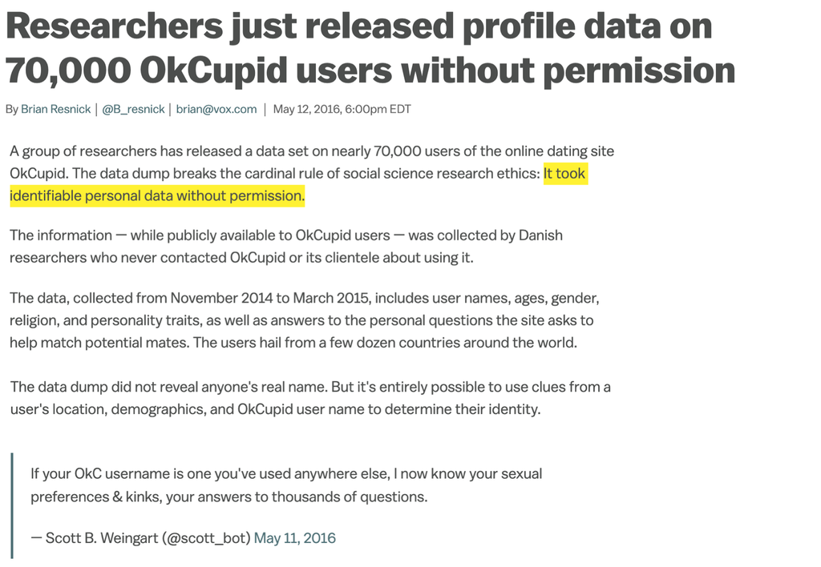

Source: Brian Resnick, [Researchers just released profile data on 70,000 OkCupid users without permission](https://www.vox.com/2016/5/12/11666116/70000-okcupid-users-data-release), Vox.

## “Can you?” vs “Should you?”

[figure not shown]

## Challenges: Unreliable formatting

[figure not shown]

alumni.duke.edu/news/notable-alumni

## Challenges: Data broken into many pages

[figure not shown]